# Assessment 01 - Parameters and Estimates

Gabriele Mineo - Harvard Data Science Professional

## **Polling - expected value of S**

Suppose you poll a population in which a proportion $\ p$ of voters are Democrats and $\ 1−p$ are Republicans. Your sample size is $\ N=25$. Consider the random variable $\ S$, which is the total number of Democrats in your sample.

What is the expected value of this random variable $\ S$?

Possible Answers

- $\ E(S)=25(1−p)$
- $\ E(S)=25p$ [X]
- $\ E(S)=\sqrt{25 p (1-p)}$
- $\ E(S)=p$

## **Polling - standard error of S**

Again, consider the random variable S, which is the total number of Democrats in your sample of 25 voters. The variable p describes the proportion of Democrats in the sample, whereas 1−p describes the proportion of Republicans.

What is the standard error of S?

Possible Answers

- $\ SE(S)=25p(1−p)$
- $\ SE(S)=\sqrt{25p}$
- $\ SE(S)=25(1−p)$
- $\ SE(S)=\sqrt{25 p (1-p)}$ [X]

## **Polling - expected value of X-bar**

Consider the random variable $\ S/N$, which is equivalent to the sample average that we have been denoting as $\ \bar{X}$. The variable $\ N$ represents the sample size and $\ p$ is the proportion of Democrats in the population.

What is the expected value of $\ \bar{X}$?

Possible Answers

- $\ E(\bar{X})=p$ [X]
- $\ E(\bar{X})=Np$
- $\ E(\bar{X})=N(1−p)$
- $\ E(\bar{X})=1−p$

## **Polling - standard error of X-bar**

What is the standard error of the sample average, $\ \bar{X}$?

The variable $\ N$ represents the sample size and $\ p$ is the proportion of Democrats in the population.

Possible Answers

- $\ SE(\bar{X})=\sqrt{Np(1−p)}$
- $\ SE(\bar{X})=\sqrt{p(1−p)/N}$ [X]
- $\ SE(\bar{X})=\sqrt{p(1−p)}$
- $\ SE(\bar{X})=\sqrt{N}$

## **se versus p**

Write a line of code that calculates the standard error `se` of a sample average when you poll 25 people in the population. Generate a sequence of 100 proportions of Democrats `p` that vary from 0 (no Democrats) to 1 (all Democrats).

Plot `se` versus `p` for the 100 different proportions.

Instructions

- Use the `seq` function to generate a vector of 100 values of `p` that range from 0 to 1.
- Use the `sqrt` function to generate a vector of standard errors for all values of `p`.
- Use the `plot` function to generate a plot with `p` on the x-axis and `se` on the y-axis.

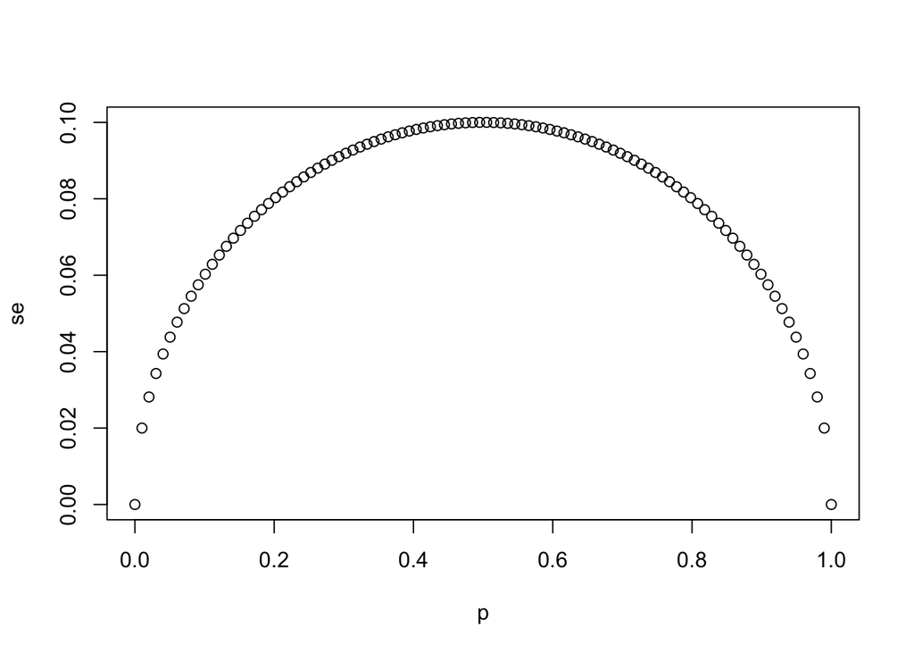

```r
# `N` represents the number of people polled
N <- 25

# Create a variable `p` that contains 100 proportions ranging from 0 to 1 using the `seq` function
p <- seq(0, 1, length = 100)

# Create a variable `se` that contains the standard error of each sample average
se <- sqrt(p*(1-p)/N)

# Plot `p` on the x-axis and `se` on the y-axis
plot(p, se)
```

## **Multiple plots of se versus p**

Using the same code as in the previous exercise, create a for-loop that generates three plots of `p` versus `se` when the sample sizes equal N=25, N=100, and N=1000.

Instructions

- Your for-loop should contain two lines of code to be repeated for three different values of N.
- The first line within the for-loop should use the `sqrt` function to generate a vector of standard errors `se` for all values of `p`.
- The second line within the for-loop should use the `plot` function to generate a plot with `p` on the x-axis and `se` on the y-axis.
- Use the `ylim` argument to keep the y-axis limits constant across all three plots. The lower limit should be equal to 0 and the upper limit should equal the highest calculated standard error across all values of `p` and `N`.

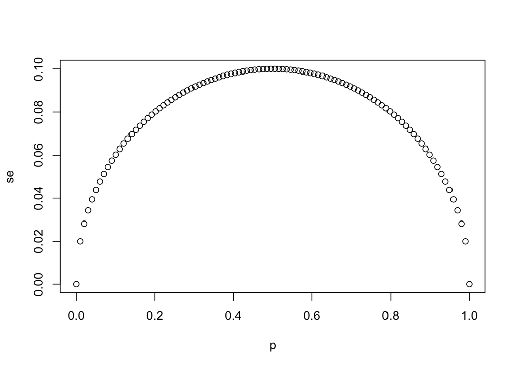

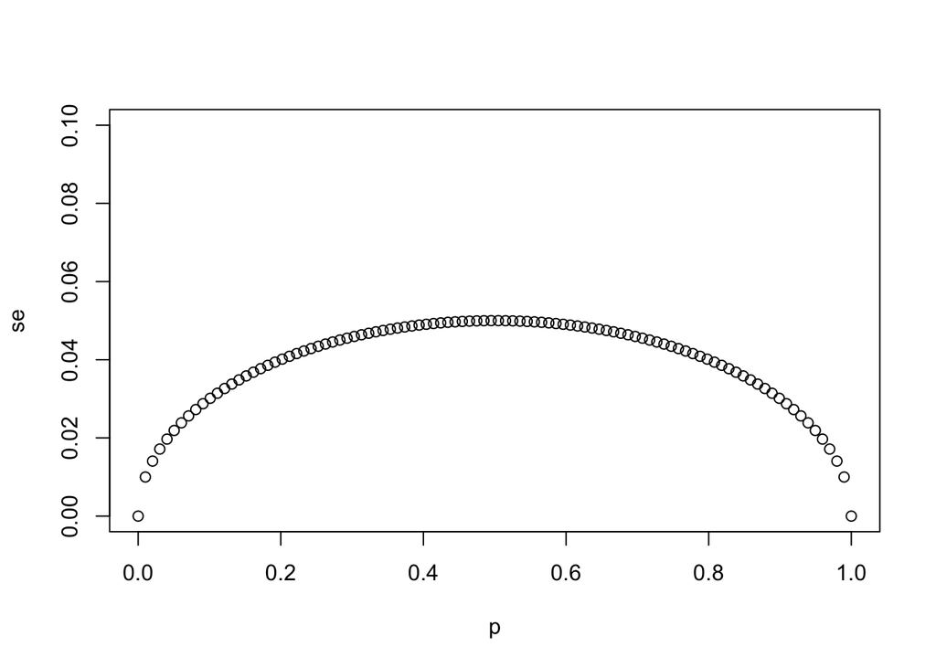

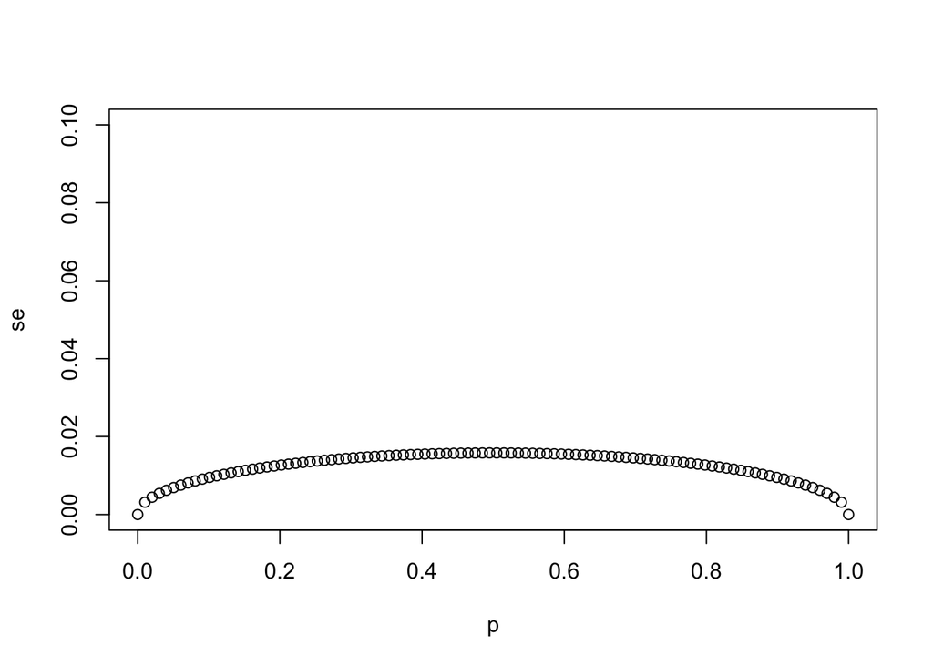

```r
# The vector `p` contains 100 proportions of Democrats ranging from 0 to 1 using the `seq` function
p <- seq(0, 1, length = 100)

# The vector `sample_sizes` contains the three sample sizes
sample_sizes <- c(25, 100, 1000)

# Write a for-loop that calculates the standard error `se` for every value of `p` for each of the three samples sizes `N` in the vector `sample_sizes`. Plot the three graphs, using the `ylim` argument to standardize the y-axis across all three plots.
for(N in sample_sizes){
  se <- sqrt(p*(1-p)/N)
  plot(p, se, ylim = c(0,0.5/sqrt(25)))
}
```

## **Expected value of d**

Our estimate for the difference in proportions of Democrats and Republicans is $\ d=\bar{X}−(1−\bar{X})$.

Which derivation correctly uses the rules we learned about sums of random variables and scaled random variables to derive the expected value of d?

Possible Answers

- $\ E[\bar{X}−(1−\bar{X})]=E[2\bar{X}−1] =2E[\bar{X}]−1 = N(2p−1) = Np−N(1−p)$
- $\ E[\bar{X}−(1−\bar{X})]=E[\bar{X}−1] =E[\bar{X}]−1 =p−1$
- $\ E[\bar{X}−(1−\bar{X})]=E[2\bar{X}−1] =2E[\bar{X}]−1 =2\sqrt{p(1−p)}−1 =p−(1−p)$
- $\ E[\bar{X}−(1−\bar{X})]=E[2\bar{X}−1] =2E[\bar{X}]−1 =2p−1 =p−(1−p)$ [X]

## **Standard error of d**

Our estimate for the difference in proportions of Democrats and Republicans is $\ d=\bar{X}−(1−\bar{X})$.

Which derivation correctly uses the rules we learned about sums of random variables and scaled random variables to derive the standard error of $\ d$?

Possible Answers

- $\ SE[\bar{X}−(1−\bar{X})]=SE[2\bar{X}−1] =2SE[\bar{X}] =2\sqrt{p/N}$
- $\ SE[\bar{X}−(1−\bar{X})]=SE[2\bar{X}−1]=2SE[\bar{X}−1]=2\sqrt{p(1−p)/N}−1$
- $\ SE[\bar{X}−(1−\bar{X})]=SE[2\bar{X}−1] =2SE[\bar{X}] =2\sqrt{p(1−p)/N}$ [X]
- $\ SE[\bar{X}−(1−\bar{X})]=SE[\bar{X}−1] =SE[\bar{X}] =\sqrt{p(1−p)/N}$

## **Standard error of the spread**

Say the actual proportion of Democratic voters is $\ p=0.45$. In this case, the Republican party is winning by a relatively large margin of $\ d=−0.1$, or a 10% margin of victory. What is the standard error of the spread $\ 2\bar{X}−1$ in this case?

Use the `sqrt` function to calculate the standard error of the spread $\ 2\bar{X}−1$.

```r
# `N` represents the number of people polled
N <- 25

# `p` represents the proportion of Democratic voters
p <- 0.45

# Calculate the standard error of the spread. Print this value to the console.
print(2*sqrt(p*(1-p)/N))
```

```
## [1] 0.1989975
```

## **Sample size**

So far we have said that the difference between the proportion of Democratic voters and Republican voters is about 10% and that the standard error of this spread is about 0.2 when N=25. Select the statement that explains why this sample size is sufficient or not.

Possible Answers

- This sample size is sufficient because the expected value of our estimate $\ 2\bar{X}−1$ is d so our prediction will be right on.
- This sample size is too small because the standard error is larger than the spread. [X]
- This sample size is sufficient because the standard error of about 0.2 is much smaller than the spread of 10%.
- Without knowing `p`, we have no way of knowing that increasing our sample size would actually improve our standard error.